# Introduction to rblocks

Nelson Areal

2015-08-18

`rblocks` whas created by [Ramnath Vaidyanathan](http://ramnathv.github.io/) and he describes the package functionality on this blog post: [rblocks Package v 0.1 · Addicted to R](http://ramnathv.github.io/posts/rblocks-pkg/)

My fork added some functionality to the package, namely the ability to output the contents of the objects created using the function `make_block`, as well as the index of each element. Printing the output contents currently works for vectors, matrices and data frames.

This is particularly useful to create blocks when creating materials to teach about R data structures and how to subset them. It is not intended to be used directly by someone learning R. There is a nice discussion about [print values inside blocks](https://github.com/ramnathv/rblocks/issues/1) on github [issues page for ramnathv/rblocks](https://github.com/ramnathv/rblocks/issues).

## Install and load the package

To install run:

```r
devtools::install_github('rblocks', 'nareal')
```

and then load the package:

```r
library(rblocks)
```

## Examples

It is possible to create vectors, matrices, data frames and lists.

### Vector

Create blocks representing a vector by just specifying its size:

```r
a_vector <- make_block(7, type = "vector")
a_vector
```

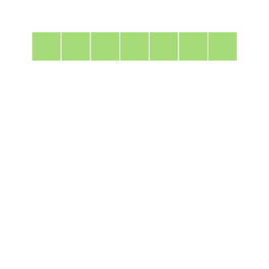

It is also possible to create the blocks from an existing vector preserving its contents

```r
b_vector <- make_block(7:1, type = "vector")
b_vector
```

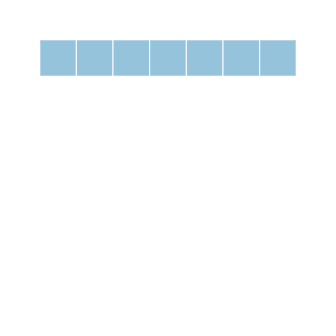

The original contents is stored as an attribute:

```r
attributes(b_vector)
```

```
## $class
## [1] "block"     "character"
##
## $original_data
## [1] 7 6 5 4 3 2 1
```

It is now possible to show the vector indices:

```r
display(b_vector, show_indices = T)
```

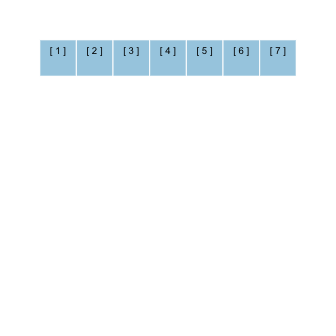

as well as its contents:

```r
display(b_vector, show_indices = T, show_data = T)
```

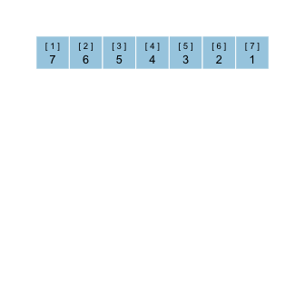

### Matrix

Again a matrix block can be created by specifing the type and matrix size:

```r
a_matrix <- make_block(3, 5, type = "matrix")
a_matrix
```

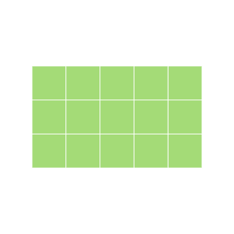

We can also display the indices:

```r
display(a_matrix, show_indices = T)
```

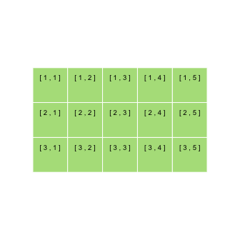

If the matrix block is created from an existing matrix, we will be able to display its original contents:

```r
my_matrix <- matrix(1:10, nrow = 5, ncol = 2)
b_matrix <- make_block(my_matrix, type = "matrix")
display(b_matrix, show_data = T)
```

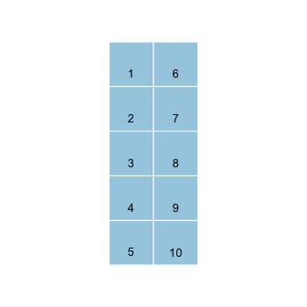

### Data frame

```r
a_dataframe <- make_block(5, 5, type = "data.frame")
a_dataframe
```

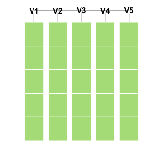

or using an existing `data.frame`

```r
mydf <- data.frame(a=1:2, b=2:3)
b_dataframe <- make_block(mydf, type = "data.frame")
b_dataframe
```

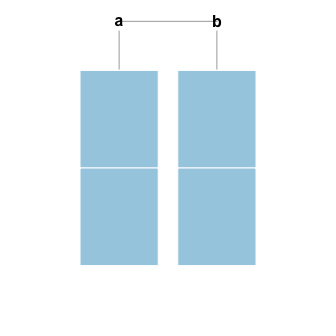

If the blocks are created from an existing `data.frame`, its contents will be stored, and can be displayed:

```r
display(b_dataframe, show_indices = T, show_data = T)
```

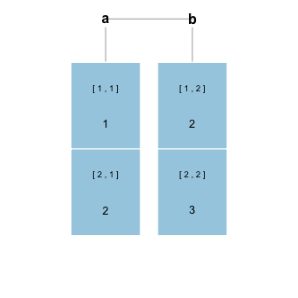

along with its indices:

```r
display(b_dataframe, show_indices = T, show_data = T)
```

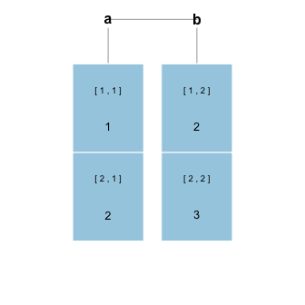

### List

```r
a_list <- make_block(list(x = 1:2, y = LETTERS[1:4], z = c(T, F)))
a_list
```

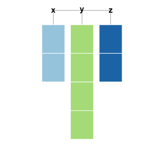

Currently it is only possible to display the list indices:

```r
display(a_list, show_indices = T)
```

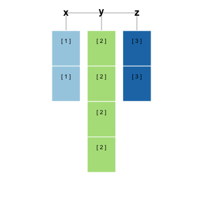

## Using `rblocks` to visualize split-apply-combine operations

From: [Visualize split-apply-combine operations · Issue #8 · ramnathv/rblocks](https://github.com/ramnathv/rblocks/issues/8)

```r
library(rblocks)
d1 <- data.frame(x = 1:6, y = rep(LETTERS[1:3], 2), stringsAsFactors = F)

m <- rbind(c(1, 2, 0), c(1, 3, 5), c(1, 4, 0))
layout(m)
display(d1, show_values = TRUE)
library(plyr)
h = ddply(d1, "y", function(x){
  display(x, show_values = TRUE)
  summarise(x, avg = mean(x))
})

display(h, show_values = TRUE)
```

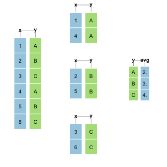

## How to customize fill color using a fill_by function.

It is possible to customise the fill color of the blocks by a function. The example below will give different colors to blocks depending on their type:

```r
fill_by <- function(f){
  function(x){
    switch(f(x), 'numeric' = "#a6cee3", 'logical' = "#1f78b4", "#b2df8a")
  }
}
options(fill_by = fill_by(mode))
getOption('fill_by', function(x){return("#b2df8a")})(1)
```

```
## [1] "#a6cee3"
```

Lets try with a list:

```r
a_list <- make_block(list(x = 1:2, y = LETTERS[1:4], z = c(T, F)))
display(a_list, show_indices = T)
```

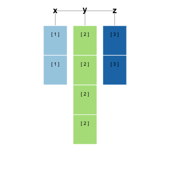